# Fake NHS Trust: Database inventory and column profile

Published

October 24, 2026

**46** tables and views, **523** columns, **30,233** rows in total. Profiled 523 columns in 46 tables in 2 seconds.

Last run started 2026-10-24 20:00:22 UTC against `/home/runner/work/_temp/Library/DBinventory/extdata/fakehosp.sqlite` (sqlite dialect), sampling tables above 1,000,000 rows, top 10 values per column, literal values suppressed for identifiers, free text and personal-data names.

## Tables

Ranked by row count. `newest_datetime` is the latest value in any date or datetime column, the freshness signal. Tables with no datetime column show blank.

| table_schema | table_name | table_type | n_columns | row_count | size | newest_datetime | newest_datetime_column |
| --- | --- | --- | --- | --- | --- | --- | --- |
| main | agg_apc_monthly | table | 13 | 1000 |  | 2026-03-01 | month |
| main | agg_daily_flow | table | 9 | 1000 |  | 2026-03-31 | flow_date |
| main | agg_did_extract | table | 18 | 1000 |  | 2026-05-03 | date_test_report_issued |
| main | agg_midnight_census | table | 5 | 1000 |  | 2026-03-31 | census_date |
| main | agg_op_monthly | table | 11 | 1000 |  | 2026-03-01 | month |
| main | beds | table | 7 | 1000 |  |  |  |
| main | derived_ed_attendances | table | 27 | 1000 |  | 2026-04-01 01:14:33 | departure_first |
| main | derived_endoscopy_procedures | table | 27 | 1000 |  | 2026-03-31 09:23:00 | start_datetime |
| main | derived_episodes | table | 11 | 1000 |  | 2026-04-01 08:20:43 | epistart |
| main | derived_imaging_exams | table | 32 | 1000 |  | 2026-05-25 23:04:30 | verified_datetime |

[output cut: 36 more lines]

### Freshness

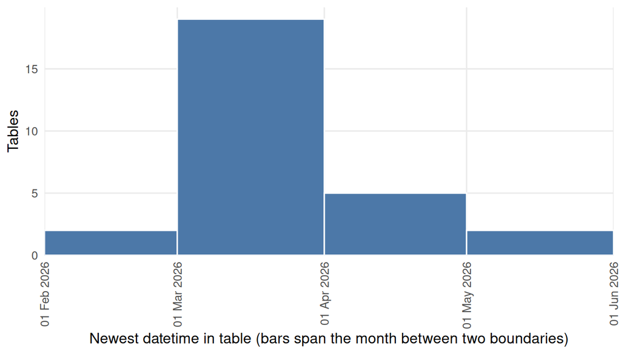

### Row counts

Bins are log-spaced so that reference tables and multi-million-row logs both show; each bar covers the row counts between the two boundaries it sits on. Bars are not equal widths because 1 to 2 and 5 to 10 each double, while 2 to 5 is a factor of 2.5.

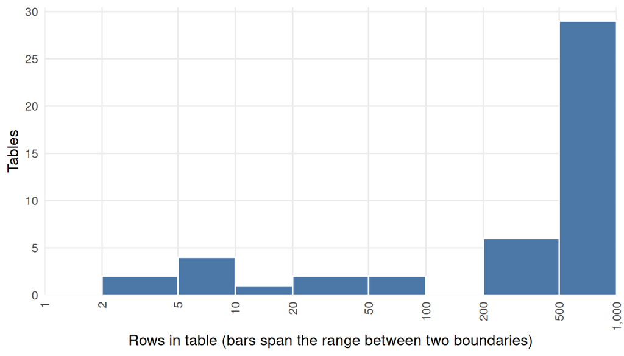

## Columns

### Type mix

| type_class | columns |
| --- | --- |
| string | 314 |
| integer | 78 |
| datetime | 54 |
| date | 33 |
| boolean | 23 |
| numeric | 21 |

### Inferred semantic types

A first draft: `identifier`, `code`, `category`, `flag`, `date`, `datetime`, `free_text`, `count`, `measure`, `constant`, `empty`. For a person to confirm, not a finding.

| semantic_type | columns |
| --- | --- |
| code | 158 |
| identifier | 88 |
| count | 71 |
| datetime | 54 |
| category | 44 |
| date | 35 |
| flag | 35 |
| measure | 21 |
| free_text | 10 |
| constant | 4 |
| time | 2 |
| empty | 1 |

### Nulls and uniqueness

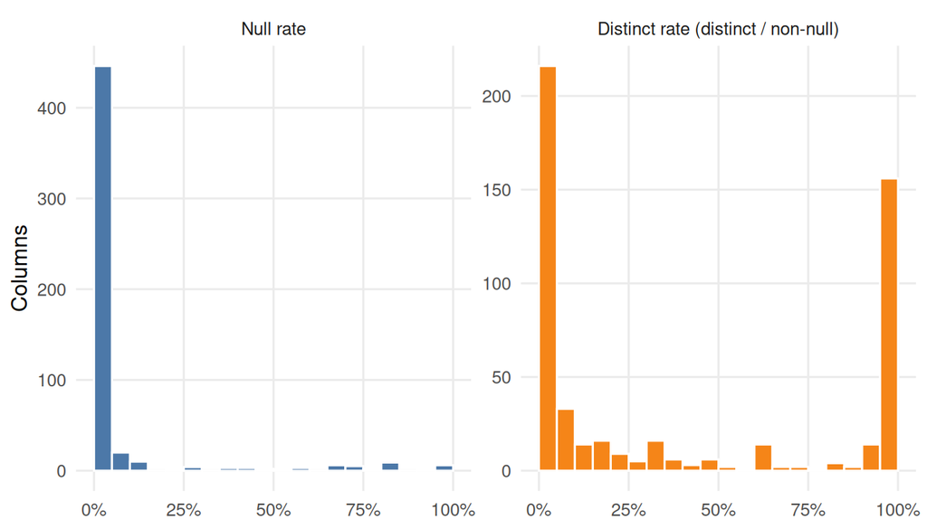

**1** columns are entirely null and **4** hold a single constant value: candidates to drop from any dictionary.

## Candidate duplicate columns

Groups of columns in different tables whose contents look the same: same type class, same order of magnitude of distinct values, same minimum and maximum and the same most frequent values, hashed together as a fingerprint. Each row is one group, listing every column in it; a group spanning a source table and a derived table is probably a copy, and columns matching under different names are the ones worth checking first. It is a starting point for the duplicate map, not a verdict: value-overlap tests confirm or reject it in the next stage.

| fingerprint | n_columns | n_tables | columns |
| --- | --- | --- | --- |
| 32757a55884a8994 | 5 | 5 | main.agg_ae_monthly.monthmain.agg_apc_monthly.monthmain.agg_did_monthly.monthmain.agg_endoscopy_monthly.monthmain.agg_op_monthly.month |
| 06886b7fec5f92bd | 4 | 4 | main.agg_did_extract.imaging_code_nicipmain.derived_imaging_exams.nicip_codemain.exam_catalogue.exam_codemain.ris_imaging.nicip_code |
| d38175c89edbddd1 | 3 | 3 | main.agg_did_extract.imaging_code_snomedmain.derived_imaging_exams.snomed_codemain.ris_imaging.snomed_code |
| 0fad08aa8213f691 | 3 | 2 | main.derived_op_appointments.mrn_as_recordedmain.derived_op_appointments.person_idmain.pas_outpatient_appointments.mrn |
| 047a9e37390687a1 | 2 | 2 | main.derived_op_appointments.referral_idmain.pas_outpatient_appointments.referral_id |
| 1776654a21368dd1 | 2 | 2 | main.agg_dm01_snapshot.month_endmain.agg_rtt_incomplete.month_end |
| 1a7f340b5e9bb4f8 | 2 | 2 | main.derived_imaging_exams.scanner_idmain.ris_imaging.scanner_id |
| 2447ad02ac672332 | 2 | 2 | main.derived_op_appointments.clinic_codemain.pas_outpatient_appointments.clinic_code |
| 411b4e7f9d5540bf | 2 | 2 | main.derived_op_appointments.consultant_codemain.pas_outpatient_appointments.consultant_code |
| 443e6e5144bb3277 | 2 | 2 | main.derived_op_appointments.dnadatemain.pas_outpatient_appointments.dna_date |

[output cut: 9 more lines]

## Foreign key candidates

Columns that look like references to a key column in another table, scored from profile statistics alone. **These are candidates, not confirmed relationships**: confirming one needs a match-rate query (what share of the child’s values exist in the key), which is the key register’s job in the next stage.

A pair is excluded outright when the types differ, the child’s string lengths fall outside the key’s, a unique child shares the key’s fingerprint (a copy, not a reference), the key’s full value set is known and the child uses a value outside it, the child has more distinct values than a fully profiled key, the shapes of their values do not overlap (`100` cannot reference `Ward 3`), the child is a flag, the key is in the child’s own table without a self-referencing name, or the child is itself a key with no name evidence. Surviving pairs start at 0.1 and add: name evidence (0.45 same name, 0.3 child name ends with the key name, 0.2 child name contains the key’s table stem; generic names like `id` or `code` earn nothing); up to 0.4 when every child value is in the key’s known value set, scaled by how much of the set the child uses; 0.25 (or -0.25) for the child’s range lying inside (or outside) the key’s when the value set is unknown; 0.15 for a many-to-one shape or 0.05 for one-to-one; 0.1 for identical string lengths. The best target at or above 0.6 is reported; `n_targets` counts the keys that qualified, since a conformed code such as a site code legitimately matches several. Full detail: `?infer_foreign_keys`.

| child | target | confidence | n_targets | child_sampled | evidence |
| --- | --- | --- | --- | --- | --- |
| main.agg_ae_monthly.site_code | main.sites.site_code | 1 | 1 | False | name=exactvalues=within(1 of 2)range=unknowncardinality=many_to_onelength=match |
| main.agg_apc_monthly.site_code | main.sites.site_code | 1 | 1 | False | name=exactvalues=within(2 of 2)range=unknowncardinality=many_to_onelength=match |
| main.agg_daily_flow.site_code | main.sites.site_code | 1 | 1 | False | name=exactvalues=within(2 of 2)range=unknowncardinality=many_to_onelength=match |
| main.agg_did_extract.provider_site_code | main.sites.site_code | 1 | 1 | False | name=suffixvalues=within(2 of 2)range=unknowncardinality=many_to_onelength=match |
| main.agg_endoscopy_monthly.site_code | main.sites.site_code | 1 | 1 | False | name=exactvalues=within(2 of 2)range=unknowncardinality=many_to_onelength=match |
| main.agg_midnight_census.site_code | main.sites.site_code | 1 | 1 | False | name=exactvalues=within(2 of 2)range=unknowncardinality=many_to_onelength=match |
| main.agg_midnight_census.ward_id | main.wards.ward_id | 1 | 1 | False | name=exactvalues=unknownrange=withincardinality=many_to_onelength=match |
| main.agg_op_monthly.site_code | main.sites.site_code | 1 | 1 | False | name=exactvalues=within(2 of 2)range=unknowncardinality=many_to_onelength=match |
| main.beds.site_code | main.sites.site_code | 1 | 1 | False | name=exactvalues=within(2 of 2)range=unknowncardinality=many_to_onelength=match |
| main.beds.ward_id | main.wards.ward_id | 1 | 1 | False | name=exactvalues=unknownrange=withincardinality=many_to_onelength=match |

[output cut: 88 more lines]

## Column profile

`pk_candidate` marks columns that are unique, never null and of a type keys are made of; where `sampled` is true that is evidence from the sample only. `fk_candidate` and `fk_target` give the key column this column most looks like a reference to, with `fk_confidence` from 0 to 1 (see the foreign key candidates section above); both are blank for the many columns that are not candidates. `top_values` lists the most frequent values with their counts; blank where values are suppressed or the column has too many distinct values for a frequency table to be useful.

| table_schema | table_name | column_name | data_type | semantic_type | row_count | null_rate | distinct_count | distinct_rate | is_unique | pk_candidate | fk_candidate | fk_target | fk_confidence | min_value | max_value | mean_value | top_values | sampled |
| --- | --- | --- | --- | --- | --- | --- | --- | --- | --- | --- | --- | --- | --- | --- | --- | --- | --- | --- |
| main | admission_method | code | TEXT | code | 11 | 0 | 11 | 1 | True | True | False |  |  | 11 | 81 |  | 11 (1);12 (1);13 (1);21 (1);22 (1);23 (1);24 (1);28 (1);2B (1);2D (1);81 (1) | False |
| main | admission_method | description | TEXT | category | 11 | 0 | 10 | 0.909 | False | False | False |  |  | Accident and emergency department of this provider | Waiting list |  | Other emergency admission (2);Accident and emergency department of this provider (1);Bed bureau (1);Booked (1);Consultant clinic (1);General practitioner (1);Planned (1);Transfer of an admitted patien… | False |
| main | admission_method | group | TEXT | code | 11 | 0 | 3 | 0.273 | False | False | False |  |  | elective | other |  | emergency (7);elective (3);other (1) | False |
| main | admission_source | code | TEXT | code | 5 | 0 | 5 | 1 | True | True | False |  |  | 19 | 87 |  | 19 (1);29 (1);51 (1);54 (1);87 (1) | False |
| main | admission_source | description | TEXT | category | 5 | 0 | 5 | 1 | True | True | False |  |  | Care home | Usual place of residence |  | Care home (1);NHS other hospital provider ward for general patients (1);Non-NHS run hospital (1);Temporary place of residence (1);Usual place of residence (1) | False |
| main | agg_ae_monthly | month | DATE | date | 72 | 0 | 36 | 0.5 | False | False | False |  |  | 2023-04-01 | 2026-03-01 |  | 2023-04-01 (2);2023-05-01 (2);2023-06-01 (2);2023-07-01 (2);2023-08-01 (2);2023-09-01 (2);2023-10-01 (2);2023-11-01 (2);2023-12-01 (2);2024-01-01 (2);2024-02-01 (2);2024-03-01 (2);2024-04-01 (2);2024-… | False |
| main | agg_ae_monthly | site_code | TEXT | constant | 72 | 0 | 1 | 0.014 | False | False | True | main.sites.site_code | 1 | RZ901 | RZ901 |  | RZ901 (72) | False |
| main | agg_ae_monthly | department_type | TEXT | code | 72 | 0 | 2 | 0.028 | False | False | False |  |  | Type 1 | Type 3 |  | Type 1 (36);Type 3 (36) | False |
| main | agg_ae_monthly | attendances | BIGINT | count | 72 | 0 | 64 | 0.889 | False | False | False |  |  | 360 | 786 | 561.931 | 682 (3);381 (2);401 (2);415 (2);423 (2);426 (2);740 (2);360 (1);371 (1);384 (1) | False |
| main | agg_ae_monthly | within_4h | BIGINT | count | 72 | 0 | 65 | 0.903 | False | False | False |  |  | 327 | 567 | 431.903 | 394 (3);403 (3);368 (2);374 (2);435 (2);327 (1);337 (1);343 (1);344 (1);349 (1) | False |

[output cut: 513 more lines]